# Exercises Part 5: Visualization

Christina Maimone

2017-09-09

# Setup

```r
library(tidyverse)
library(gapminder)
data(gapminder)
```

# Exercise: Make a Line Plot

Using the `gapminder` data, make a line plot showing the population of Afghanistan over time. Do this first with base R plotting and then with `ggplot`. Hint: for base R, look at the help for `plot.default` and the `type` parameter. For `ggplot`, use the cheat sheet to find the correct geom to use.

Make sure to clean up the x and y labels, and give your plot a title.

### Answer

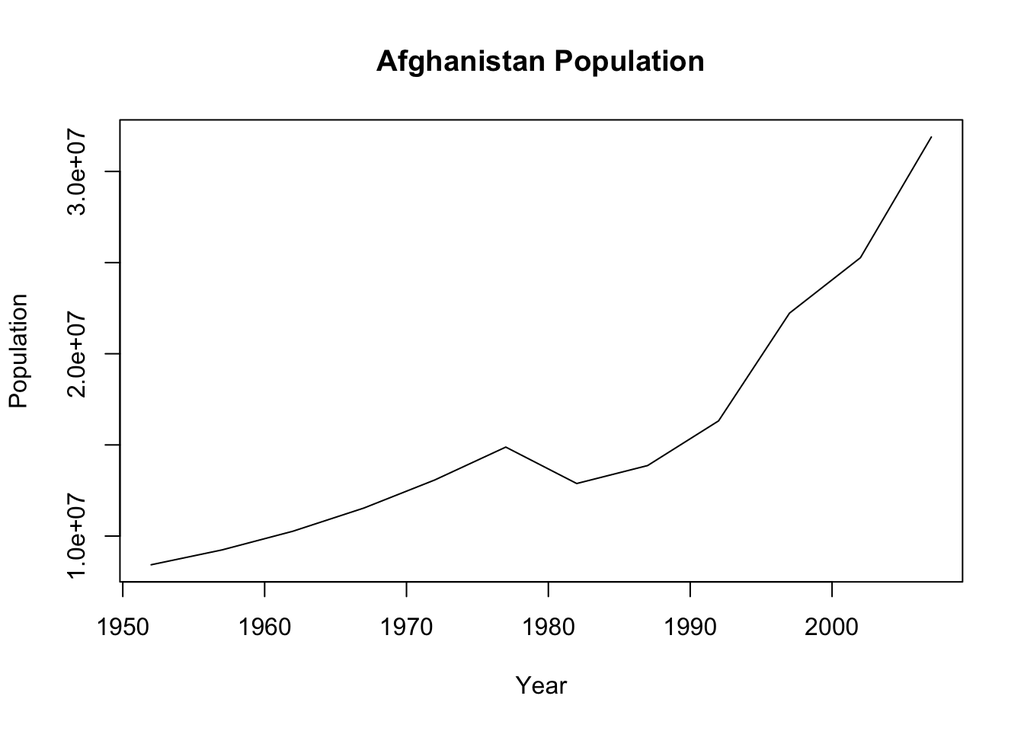

```r
# base R
plot(x=gapminder$year[gapminder$country=="Afghanistan"],
     y=gapminder$pop[gapminder$country=="Afghanistan"],
     type="l",
     xlab="Year",
     ylab="Population",
     main="Afghanistan Population")
```

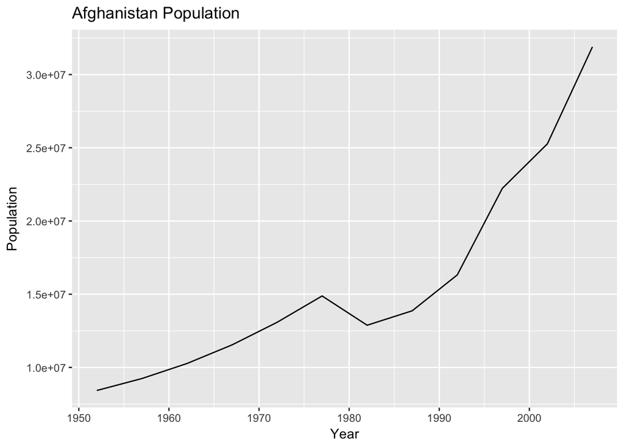

```r
# ggplot
filter(gapminder, country=="Afghanistan") %>%
ggplot(aes(y=pop, x=year)) +
  geom_line() +
  xlab("Year") +
  ylab("Population") +
  ggtitle("Afghanistan Population")
```

# Exercise: Histogram

Make a histogram of life expectancies in 2007. Make the historgram with each of 5, 10, 20, and 40 bins. Use either base R or `ggplot` functions (or do both). Does the number of bins change your interpretation of the data at all? Do you see different trends?

### Answer

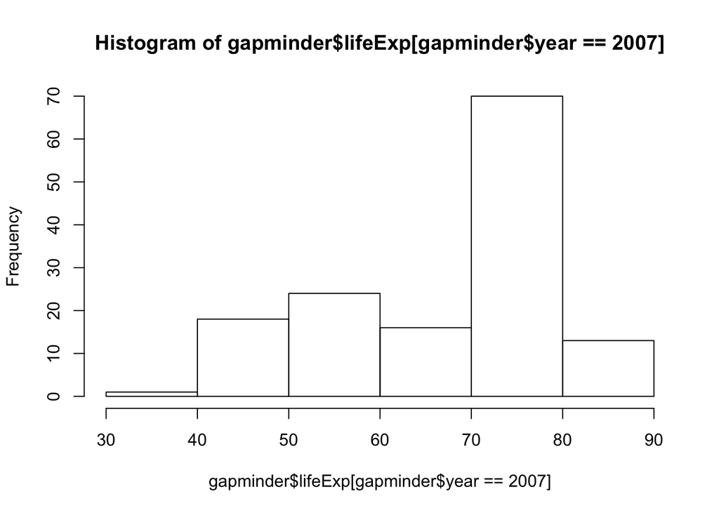

```r
## repeat, changing the number of breaks
hist(gapminder$lifeExp[gapminder$year==2007], breaks=5)
```

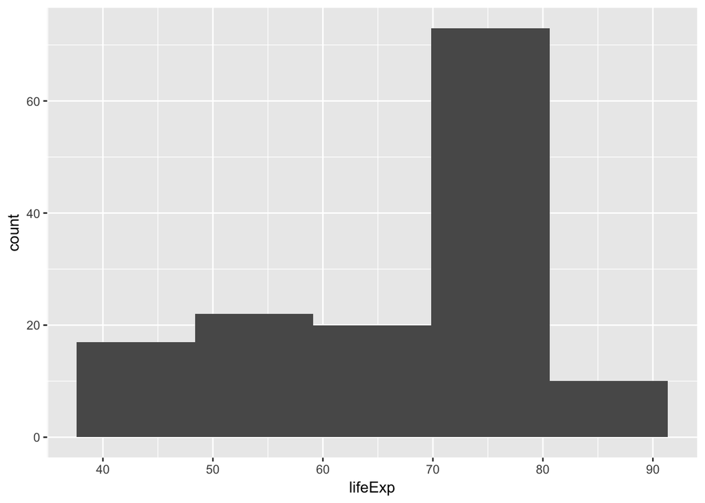

```r
# or, with ggplot
filter(gapminder, year==2007) %>%
  ggplot(aes(lifeExp)) +
  geom_histogram(bins=5)
```

With more bins, ie becomes more obvious that there are at least two sets of countries in the data. There’s a cluster of high life expectancy, then a large spread of countries with lower life expectancy.

# `ggplot` Exercise: Change Colors

Using the `gapminder` data, repeat the plot we made together of life expectancy vs. GDP per capita, with points colored by continent. Instead of using the default colors, use the palette below. Hint: use `scale_colour_manual` to set the colors.

```r
cbPalette <- c("#999999", "#E69F00", "#56B4E9", "#009E73",
               "#F0E442", "#0072B2", "#D55E00", "#CC79A7")
```

### Answer

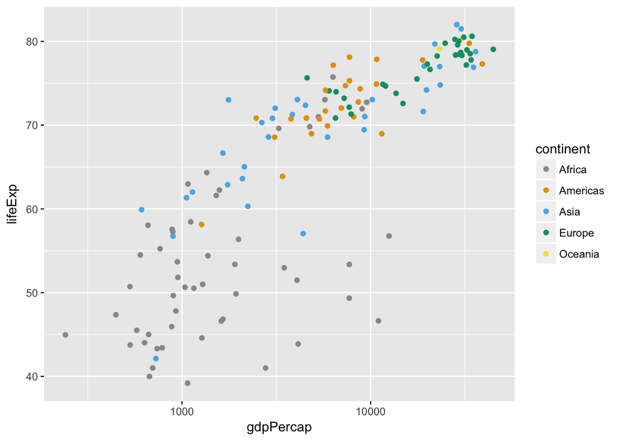

```r
filter(gapminder, year==2002) %>%
  ggplot(aes(x=gdpPercap, y=lifeExp, color=continent)) +
  geom_point() +
  scale_x_log10() +
  scale_colour_manual(values=cbPalette)
```

The example palette above is a color-blind friendly palette from http://jfly.iam.u-tokyo.ac.jp/color/ (using color-blind friendly colors for publications is a good idea even if you yourself aren’t color blind).

# `ggplot` Exercise: Multiple lines and facets

Using the `gapminder` data, create a plot to show the change in life expectancy over time. Plot one line for each country. Color the lines by continent. Include decent labels on your plot. Hint: you will set 4 aesthetics: x, y, by, and color.

Then add the points for each observation to the plot as well (so that you have a line with points on it). Hint: you can use multiple geoms in the same plot.

Then split out the countries by continent, so there is one plot per continent. Challenge: Remove the legend on this final plot, as it is redundant with the plot labeling. Hint: look at `legend.position` argument to the `theme` function.

### Answer

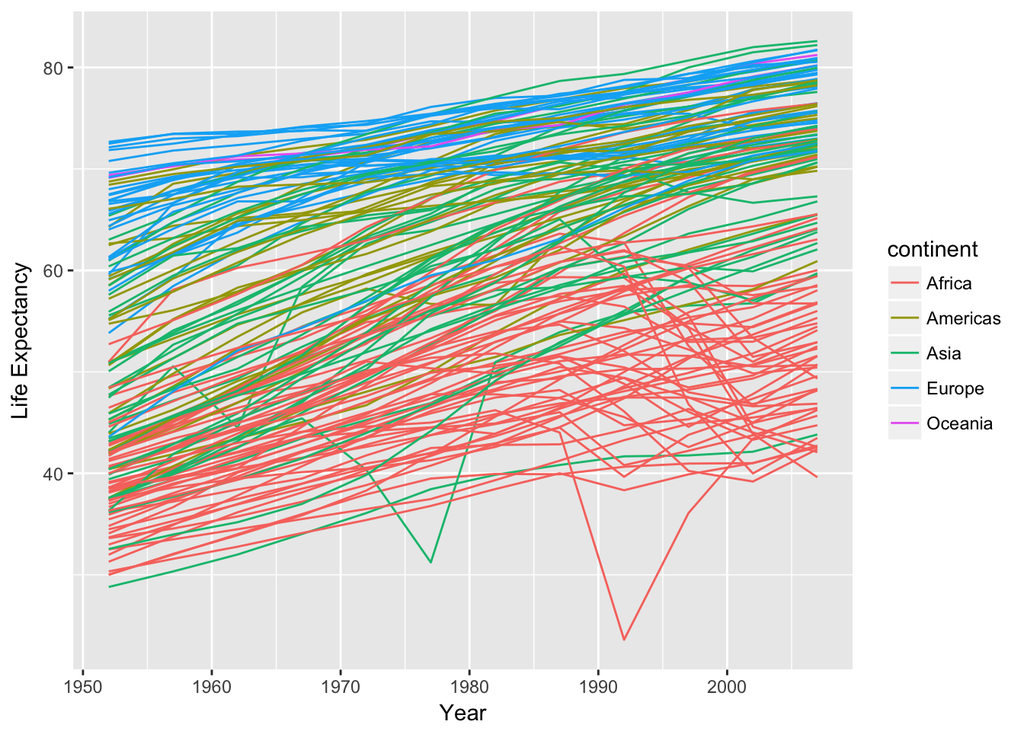

```r
ggplot(gapminder, aes(y=lifeExp,
                      x=year,
                      by=country,
                      color=continent)) +
  geom_line() +
  xlab("Year") +
  ylab("Life Expectancy")
```

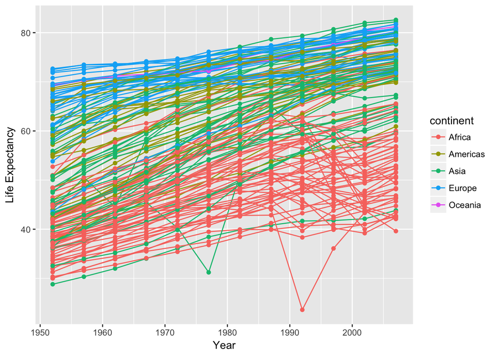

```r
ggplot(gapminder, aes(y=lifeExp,
                      x=year,
                      by=country,
                      color=continent)) +
  geom_line() +
  xlab("Year") +
  ylab("Life Expectancy") +
  geom_point()
```

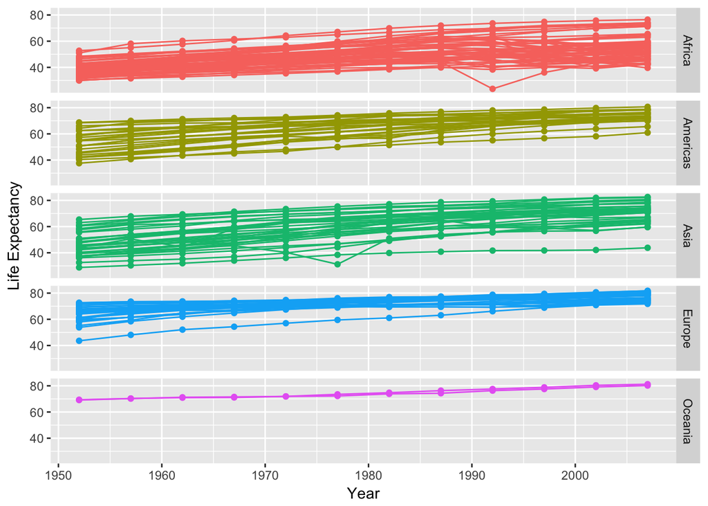

```r
ggplot(gapminder, aes(y=lifeExp,
                      x=year,
                      by=country,
                      color=continent)) +
  geom_line() +
  xlab("Year") +
  ylab("Life Expectancy") +
  geom_point() +
  facet_grid(continent ~ .) +
  theme(legend.position="none")
```

# `ggplot` Exercise: Add a Trend Line

Create a scatter plot of life expectancy vs. log of population for the year 2007. Color points by continent. Add a linear regression line for each continent. Hint: use `geom_smooth` and set `method=lm` for linear regression.

Then redo the plot with a single overall trend line (don’t worry about coloring points by continent anymore). What do you notice?

### Answer

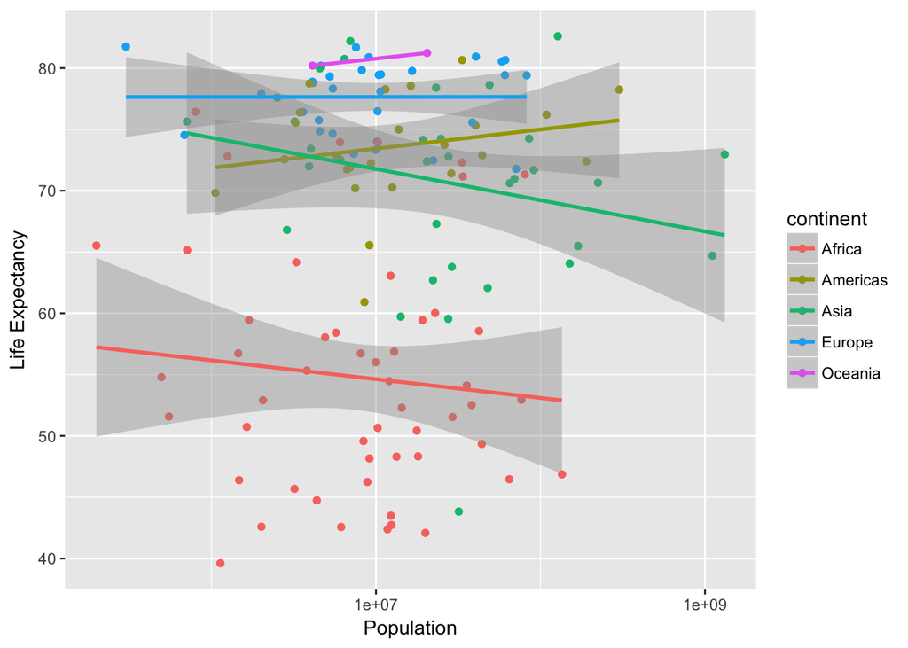

```r
filter(gapminder, year==2007) %>%
ggplot(aes(y=lifeExp, x=pop, color=continent)) +
  geom_point() +
  xlab("Population") +
  ylab("Life Expectancy") +
  geom_smooth(method=lm) +
  scale_x_log10()
```

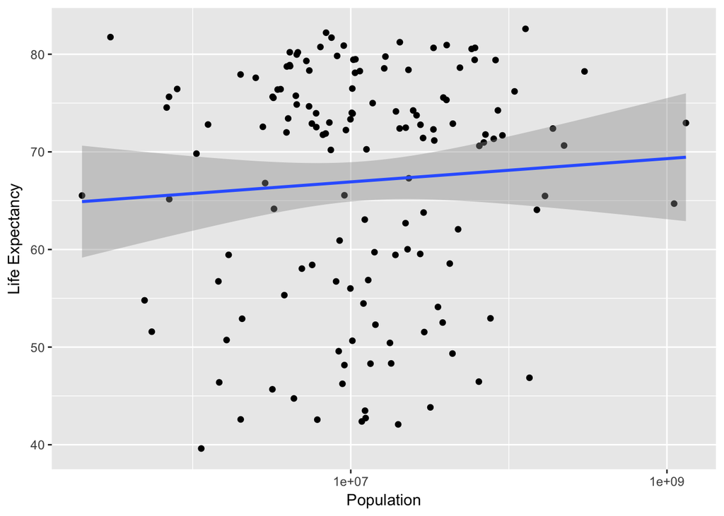

```r
filter(gapminder, year==2007) %>%
ggplot(aes(y=lifeExp, x=pop)) +
  geom_point() +
  xlab("Population") +
  ylab("Life Expectancy") +
  geom_smooth(method=lm) +
  scale_x_log10()
```

The warning message you get for the first plot is OK. It’s the result of there only being 2 Oceania countries.

Note that overall, there is a positive trend, but for several continents, the trend within the continent is negative. You might want to look up [Simpson’s Paradox](https://en.wikipedia.org/wiki/Simpson%27s_paradox).